# Societal Benefit Repo Latent Dirichlet Allocation on full texts

Author

O’Hara

```r
library(tidyverse)
library(tidytext)
library(topicmodels)
library(here)
library(ggwordcloud)
```

# Summary

The 100 unique documents included from the Societal Benefits repository have been imported into Zotero, and the pdfs copied into this repo; full text was extracted from each. Here we lemmatize the corpus of full texts for text analysis, and examine TF-IDF and LDA results.

# Data

See scripts 1 and 2 in this folder.

# Methods

## Gather full texts

Full texts were extracted from pdfs using `pdftools`, saved in `_data/societal_benefits/csv`. Each row is a sentence parsed from the pdfs using `tidytext::unnest_tokens()`. Not perfect, but good enough for government work. We’ll group the documents and summarize the sentences into an entire full text.

```r
files_df <- read_csv(here('_data/societal_benefits/int/fulltext_files.csv'))

csv_fs <- files_df$csv_out

txt_df <- lapply(here(csv_fs), data.table::fread) %>%
  setNames(csv_fs) %>%
  bind_rows(.id = 'file') %>%
  group_by(file) %>%
  summarize(fulltext = paste(p, collapse = ' '), .groups = 'drop') %>%
  mutate(doc_id = paste0('text', 1:n()))
```

## Stop: Lemmatize!

```r
fulltext_parsed_f <- here('_data/societal_benefits/int/fulltext_parsed.csv')
if(!file.exists(fulltext_parsed_f)) {
  library(spacyr)

  # spacy_install() ### installs Python (if necessary) and everything to access the spaCy package

  spacy_initialize(model = 'en_core_web_sm')

  system.time(fulltext_parsed_df <- spacy_parse(txt_df$fulltext))

  fulltext_parsed_trimmed_df <- fulltext_parsed_df %>%
    ### drop small tokens
    filter(nchar(token) > 2) %>%
    ### drop tokens with punctuation or numbers
    filter(!str_detect(token, '[[:punct:]]|[0-9]'))

  write_csv(fulltext_parsed_trimmed_df, fulltext_parsed_f)
}

fulltext_parsed_df <- read_csv(fulltext_parsed_f)
```

## Examine TF-IDF

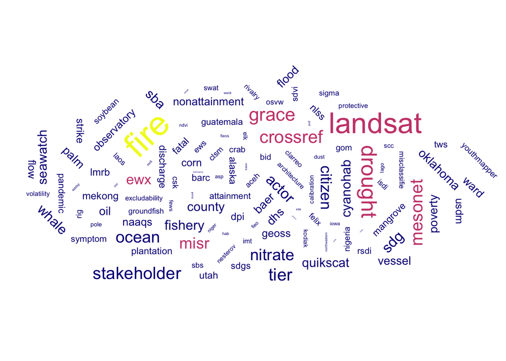

```r
tf_idf_df <- fulltext_parsed_df %>%
  group_by(doc_id, lemma) %>%
  summarize(n = n(), .groups = 'drop') %>%
  bind_tf_idf(lemma, doc_id, n) %>%
  filter(tf_idf > 0)

top_tf_idf <- tf_idf_df %>%
  filter(tf_idf > 0.02)

top_by_freq <- top_tf_idf %>%
  group_by(lemma) %>%
  summarize(n = sum(n),
            n_docs = n_distinct(doc_id)) %>%
  mutate(angle = 45 * sample(-2:2, n(),
    replace = TRUE,
    prob = c(1, 1, 4, 1, 1)
  ))

ggplot(top_by_freq, aes(label = lemma, size = n, color = log(n_docs))) +
  geom_text_wordcloud(aes(angle = angle)) +
  scale_size_area(max_size = 12) +
  scale_color_viridis_c(option = 'plasma') +
  theme_minimal()
```

## LDA

### Get data into proper format

First, let’s start with our dataframe of lemmatized full-texts, but clean it up a bit since more words (including uninformative stop words) makes it take a lot longer. Then we will cast this to a “Document Term Matrix” that summarizes how many times each word shows up in each document (similar, but not the same, as TF-IDF) - each row a document, each column a word, and each cell the number of times that word shows up in that document.

```r
fulltext_clean_df <- fulltext_parsed_df %>%
  select(doc_id, lemma) %>%
  anti_join(stop_words, by = c('lemma' = 'word')) %>%
  group_by(doc_id, lemma) %>%
  summarize(n = n(), .groups = 'drop')

fulltext_dtm <- cast_dtm(data = fulltext_clean_df,
                      term = lemma,
                      document = doc_id,
                      value = n)
```

### How many topics?

The `ldatuning` package runs four different metrics to identify a good number of topics. This takes a while (though less than manually trying each combination of k) so I’ve run it ahead of time and saved the results.

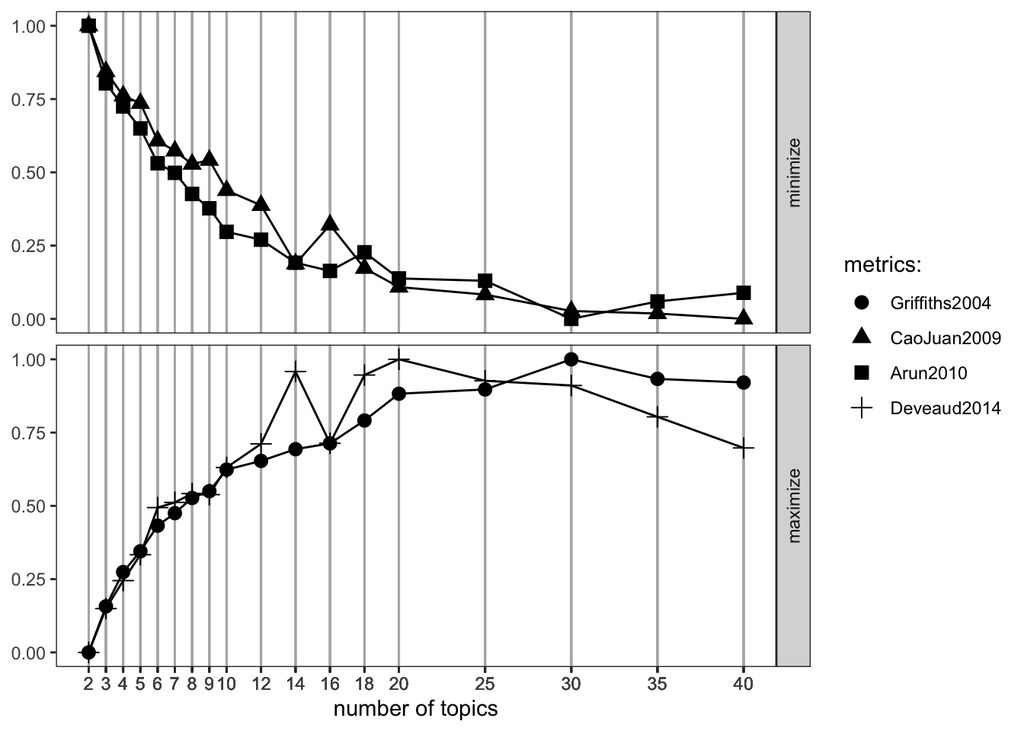

```r
tuning_f <- here('_data/societal_benefits/int/topic_tuning.csv')
if(!file.exists(tuning_f)) {
  ### remotes::install_github("nikita-moor/ldatuning")
  library(ldatuning)

  k_vec <- c(2:10, seq(12, 20, 2), seq(25, 40, 5))

  optim_topics <- FindTopicsNumber(
    fulltext_dtm,
    topics = k_vec,
    metrics = c("Griffiths2004", "CaoJuan2009", "Arun2010", "Deveaud2014"),
    control = list(seed = 12345),
    mc.cores = 4,
    verbose = TRUE
  )
  write_csv(optim_topics, tuning_f)
}

optim_topics <- read_csv(tuning_f)
ldatuning::FindTopicsNumber_plot(optim_topics)
```

Griffiths index seems to suggest about 30, before dropping slightly. CaoJuan and Arun drop sharply to about 14 with little upticks at 16 and 18 respectively before leveling off after 20; Deveaud seems to peak at 14 or 20. Based on these, let’s choose 20 topics.

### Running LDA on the full texts

```r
top_doc_f  <- here('_data/societal_benefits/out/topic_by_doc.csv')
top_term_f <- here('_data/societal_benefits/out/term_by_topic.csv')
if(any(!file.exists(top_doc_f, top_term_f))) {
  library(topicmodels)

  set.seed(42) ### doesn't seem to make the LDA repeatable though
  fulltext_lda <- topicmodels::LDA(fulltext_dtm, k = 20)

  ### Extract topics for each doc by probability
  fulltext_topics <- posterior(fulltext_lda)$topic %>%
    as.data.frame() %>%
    setNames(paste0('topic', names(.))) %>%
    mutate(doc_id = rownames(.))

  write_csv(fulltext_topics, top_doc_f)

  ### Extract terms for each topic by probability
  fulltext_terms  <- posterior(fulltext_lda)$term %>%
    as.data.frame() %>%
    mutate(topic = paste('topic', rownames(.))) %>%
    pivot_longer(cols = -topic, names_to = 'term', values_to = 'prob') #%>%
    # filter(prob > 0.0001)

  write_csv(fulltext_terms, top_term_f)
}
```

### Summarize topic modeling!

As a final step, take the top 20 terms from each topic, and ask ChatGPT to suggest a brief topic name for each.

```r
top20 <- read_csv(top_term_f) %>%
  mutate(topic = str_extract(topic, '[0-9]+') %>% as.numeric) %>%
  group_by(topic) %>%
  slice_max(order_by = prob, n = 20) %>%
  ungroup()
write_csv(top20, str_replace(top_term_f, '.csv', '_top20.csv'))
```

Note that LDA seems to have built-in stochasticity, so even with a random generator seed, the results are different every time - these topics may not match properly if the LDA is run again.

- Economic Impact of Space Activities
- Sustainable Development Goals Monitoring with Satellite Data
- Landsat and Weather Monitoring for Water Resources
- Drought Management and Agricultural Impact
- Modeling Water Conditions and Forecasting
- Earth Observation for Community Priorities
- Earth Observation Benefits and Climate Change
- Water Quality Estimation and Economic Studies
- Consumer Behavior Analysis and Economic Modeling
- National Mapping and Poverty Estimation
- Wildfire Management and Cost Analysis
- Ocean Observation Systems and Economic Assessments
- Remote Sensing for Oil Palm Production
- Drought Monitoring and Health Impact
- Landsat Imagery Benefits for Fisheries
- Global Earth Observation Policies
- Earth Science Applications for Future Studies
- Social Impact Assessment with Earth Observation Data
- Satellite Data Products and Service Providers
- Climate Region Analysis and Precipitation Forecasting

Now let’s join the topics and the titles to see whether these make sense! Let’s keep as many topics as necessary to make up 75% of the probability of the document.

```r
topic_names <- c(topic1  = 'Economic Impact of Space Activities',
                 topic2  = 'Sustainable Development Goals Monitoring with Satellite Data',
                 topic3  = 'Landsat and Weather Monitoring for Water Resources',
                 topic4  = 'Drought Management and Agricultural Impact',
                 topic5  = 'Modeling Water Conditions and Forecasting',
                 topic6  = 'Earth Observation for Community Priorities',
                 topic7  = 'Earth Observation Benefits and Climate Change',
                 topic8  = 'Water Quality Estimation and Economic Studies',
                 topic9  = 'Consumer Behavior Analysis and Economic Modeling',
                 topic10 = 'National Mapping and Poverty Estimation',
                 topic11 = 'Wildfire Management and Cost Analysis',
                 topic12 = 'Ocean Observation Systems and Economic Assessments',
                 topic13 = 'Remote Sensing for Oil Palm Production',
                 topic14 = 'Drought Monitoring and Health Impact',
                 topic15 = 'Landsat Imagery Benefits for Fisheries',
                 topic16 = 'Global Earth Observation Policies',
                 topic17 = 'Earth Science Applications for Future Studies',
                 topic18 = 'Social Impact Assessment with Earth Observation Data',
                 topic19 = 'Satellite Data Products and Service Providers',
                 topic20 = 'Climate Region Analysis and Precipitation Forecasting')

fulltext_topics <- read_csv(top_doc_f) %>%
  pivot_longer(-doc_id, names_to = 'topic', values_to = 'prob') %>%
  left_join(txt_df %>% select(-fulltext), by = 'doc_id') %>%
  left_join(files_df, by = c('file' = 'csv_out')) %>%
  select(topic, prob, title, author, year) %>%
  distinct()

doc_topics <- fulltext_topics %>%
  group_by(title) %>%
  arrange(prob) %>%
  mutate(tot = cumsum(prob)) %>%
  ungroup() %>%
  filter(tot > .25) %>%
  mutate(topic_name = topic_names[topic]) %>%
  select(-topic, -tot) %>%
  mutate(prob = round(prob, 3))
```

#### Confident topic assignments

```r
DT::datatable(doc_topics %>% filter(prob >= .75))
```

|  | prob | title | author | year | topic_name |
| --- | --- | --- | --- | --- | --- |
| 1 | 0.76 | Impact of Global Earth Observation-Systemic View across GEOSS Societal Benefit Area | Rydzak, Felicjan and Obersteiner, Michael and Kraxner, Florian | 2010 | Remote Sensing for Oil Palm Production |
| 2 | 0.794 | A User-Driven Approach to Determining Critical Earth Observation Priorities for Societal Benefit | Zell, Erica and Huff, Amy K. and Carpenter, Adam T. and Friedl, Lawrence A. | 2012 | Earth Observation for Community Priorities |
| 3 | 0.799 | POSITION PAPER - EVALUATION METHODS AND TECHNIQUES | Smart, Alan |  | Wildfire Management and Cost Analysis |
| 4 | 0.803 | Pricing Policy and Legal Issues: 6th and 7th EOPOLE Workshops | Harris, Ray and Olby, Nicola | 2000 | Global Earth Observation Policies |
| 5 | 0.806 | What Is the Economic Value of Satellite Imagery? | Raunikar, Ronald P. and Forney, William M. and Benjamin, Susan P. | 2013 | Water Quality Estimation and Economic Studies |
| 6 | 0.807 | Benefits of the Free and Open Landsat Data Policy | Zhu, Zhe and Wulder, Michael A. and Roy, David P. and Woodcock, Curtis E. and Hansen, Matthew C. and Radeloff, Volker C. and Healey, Sean P. and Schaaf, Crystal and Hostert, Patrick and Strobl, Peter … | 2019 | Earth Science Applications for Future Studies |
| 7 | 0.811 | Operational Use and Impact of Satellite Remotely Sensed Ocean Surface Vector Winds in the Marine Warning and Forecasting Environment | Chang, Paul and Jelenak, Zorena and Sienkiewicz, Joseph and Knabb, Richard and Brennan, Michael and Long, David and Freeberg, Mark | 2009 | Landsat and Weather Monitoring for Water Resources |
| 8 | 0.818 | Data Poverty: A Global Evaluation for 2009 to 2013 - Implications for Sustainable Development and Disaster Risk Reduction | Leidig, Mathias and Teeuw, Richard M. and Gibson, Andrew D. | 2016 | National Mapping and Poverty Estimation |
| 9 | 0.82 | The Value of Near Real-Time Earth Observations for Improved Flood Disaster Response | Oddo, Perry C. and Bolten, John D. | 2019 | Ocean Observation Systems and Economic Assessments |
| 10 | 0.835 | Valuing Weather Observation Systems For Forest Fire Management | Khabarov, N. and Moltchanova, E. and Obersteiner, M. | 2008 | Remote Sensing for Oil Palm Production |

[output cut: 56 more lines]

#### Mixed topic assignments

```r
DT::datatable(doc_topics %>% filter(prob < .75))
```

|  | prob | title | author | year | topic_name |
| --- | --- | --- | --- | --- | --- |
| 1 | 0.142 | Earth Observation in a Cost-Benefit Analysis Perspective: Cosmo SkyMed Satellites of the Italian Space Agency | Cl{\`o}, Stefano and Florio, Massimo and Morretta, Valentina and Vurchio, Davide |  | Social Impact Assessment with Earth Observation Data |
| 2 | 0.152 | Earth Observation in a Cost-Benefit Analysis Perspective: Cosmo SkyMed Satellites of the Italian Space Agency | Cl{\`o}, Stefano and Florio, Massimo and Morretta, Valentina and Vurchio, Davide |  | Global Earth Observation Policies |
| 3 | 0.155 | Investigating the Global Socio-Economic Benefits of Satellite Industry and Remote Sensing Applications | Alvino, Letizia and Marino, Stefano and Ahmad, Uzair and Alvino, Arturo | 2020 | Wildfire Management and Cost Analysis |
| 4 | 0.157 | Banda Aceh-The Value of Earth Observation Data in Disaster Recovery and Reconstruction: A Case Study | McCallum, I. and Kidd, R. and Fritz, S. and Kraxner, F. and Obersteiner, M. and Shvidenko, Anatoly | 2008 | Global Earth Observation Policies |
| 5 | 0.176 | Earth Observation and the Public Good | Harris, Ray and Miller, Lewis | 2011 | Global Earth Observation Policies |
| 6 | 0.182 | CEOS Contributions to Informing Energy Management and Policy Decision Making Using Space-Based Earth Observations | Eckman, Richard S. and Stackhouse, Paul W. | 2012 | Global Earth Observation Policies |
| 7 | 0.183 | Earth Observation in Service of the 2030 Agenda for Sustainable Development | Anderson, Katherine and Ryan, Barbara and Sonntag, William and Kavvada, Argyro and Friedl, Lawrence | 2017 | Earth Observation Benefits and Climate Change |
| 8 | 0.19 | Interactive Model for Assessing Mangrove Health, Ecosystem Services, Policy Consequences, and Satellite Design in Rio de Janeiro Using Earth Observation Data | Reida, Jack B. and Wood, Danielle | 2020 | Earth Science Applications for Future Studies |
| 9 | 0.197 | Visual Evidence from Above: Assessing the Value of Earth Observation Satellites for Supporting Human Rights | Notley, Tanya and {Webb-Gannon}, Camellia | 2016 | Satellite Data Products and Service Providers |
| 10 | 0.202 | The Socioeconomic Benefits of Earth Science and Applications Research: Reducing the Risks and Costs of Natural Disasters in the USA | Williamson, Ray A and Hertzfeld, Henry R and Cordes, Joseph and Logsdon, John M | 2002 | Satellite Data Products and Service Providers |

[output cut: 55 more lines]